# Lab 6

Author

MinyoungSo

# Lab 6 - Text Mining

## Setup

```r
library (dplyr)
library (ggplot2)
library (tidytext)
library (tidyverse)
```

```r
url <- 'https://raw.githubusercontent.com/dmcable/BIOSTAT620W26/main/data/mtsamples/mtsamples.csv'
if (!file.exists("mtsamples.csv"))
  download.file(
    url = url,
    destfile = "mtsamples.csv",
    method   = "libcurl",
    timeout  = 60
    )
mtsamples <- read.csv('mtsamples.csv')
dim(mtsamples)
```

```
[1] 4999    6
```

```r
str(mtsamples)
```

```
'data.frame':   4999 obs. of  6 variables:
 $ X                : int  0 1 2 3 4 5 6 7 8 9 ...
 $ description      : chr  " A 23-year-old white female presents with complaint of allergies." " Consult for laparoscopic gastric bypass." " Consult for laparoscopic gastric bypass." " 2-D M-Mode. Doppler.  " ...
 $ medical_specialty: chr  " Allergy / Immunology" " Bariatrics" " Bariatrics" " Cardiovascular / Pulmonary" ...
 $ sample_name      : chr  " Allergic Rhinitis " " Laparoscopic Gastric Bypass Consult - 2 " " Laparoscopic Gastric Bypass Consult - 1 " " 2-D Echocardiogram - 1 " ...
 $ transcription    : chr  "SUBJECTIVE:,  This 23-year-old white female presents with complaint of allergies.  She used to have allergies w"| __truncated__ "PAST MEDICAL HISTORY:, He has difficulty climbing stairs, difficulty with airline seats, tying shoes, used to p"| __truncated__ "HISTORY OF PRE…
 $ keywords         : chr  "allergy / immunology, allergic rhinitis, allergies, asthma, nasal sprays, rhinitis, nasal, erythematous, allegr"| __truncated__ "bariatrics, laparoscopic gastric bypass, weight loss programs, gastric bypass, atkin's diet, weight watcher's, "| __truncated__ "bariatrics, la…
```

## Question 1: What specialties do we have?

```r
mtsamples %>%
  count(medical_specialty, sort = TRUE)
```

```
                medical_specialty    n
1                         Surgery 1103
2      Consult - History and Phy.  516
3      Cardiovascular / Pulmonary  372
4                      Orthopedic  355
5                       Radiology  273
6                General Medicine  259
7                Gastroenterology  230
8                       Neurology  223
9   SOAP / Chart / Progress Notes  166
10        Obstetrics / Gynecology  160
11                        Urology  158
12              Discharge Summary  108
13           ENT - Otolaryngology   98
14                   Neurosurgery   94
```

[output cut: 26 more lines]

## Question 2

The most frequently appearing words are stop words such as articles and other grammatically functional words. It makes sense. To get meaningful words, we should remove them. The top 20 most frequent words were visualized and the most frequent word is “the” which is shown nearly 150,000 times. It is hard to get any insight from these words.

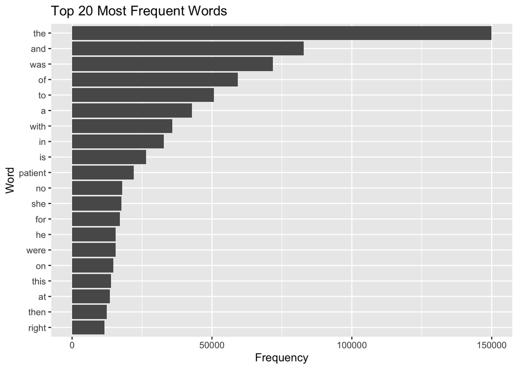

```r
# Tokenize the the words in the transcription column
tidy_words <- mtsamples %>%
  unnest_tokens(word, transcription)  #word =tokens

# Count the number of times each token appears
word_counts <- tidy_words %>%
  count(word, sort = TRUE)

# Visualize the top 20 most frequent words
word_counts %>%
  slice_max(n, n = 20) %>%
  ggplot(aes(x = reorder(word, n), y = n)) +
  geom_col() +
  coord_flip() +
  labs(title = "Top 20 Most Frequent Words",
       x = "Word",
       y = "Frequency")
```

## Question 3

Stop words were removed and the numbers as well. Now, the top 20 words give us better idea about the text. Among the 20 words the most frequently used word is “patient” with over 20,000 frequncy. From these top 20 words, we can geuss this text is related to medical context, especially related to patients.

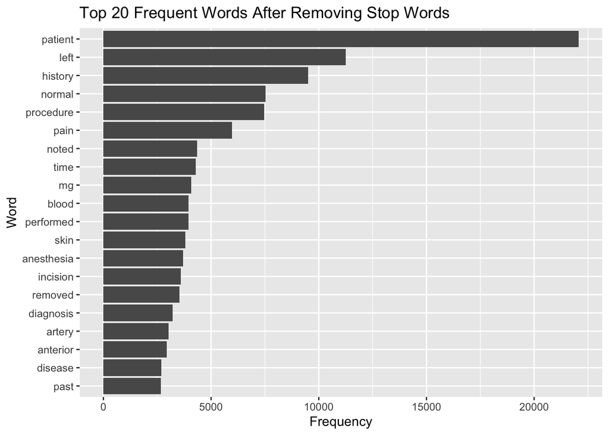

```r
# Re-do the visualization but remove stop words before making it
data("stop_words")
#stop_words

mtsamples |>
  unnest_tokens(word, transcription) |>
  anti_join(stop_words, by = c("word")) |>
  filter(!grepl("^[0-9]+$", word)) |> # Remove numbers!!!!
  count(word, sort = TRUE) |>
  slice_max(n, n = 20) |>
  ggplot(aes(n, fct_reorder(word, n))) +
  geom_col() +
  labs(
    x = "Frequency",
    y = "Word",
    title = "Top 20 Frequent Words After Removing Stop Words"
  )
```

## Question 4

The bigrams still shows a lot of stop words and hard to pick up informative phrases, but at tri-gram, the non-stop words were more shown, resulting in finding some common phrases such as the operating room, tolerated the procedure, past medical history, etc.

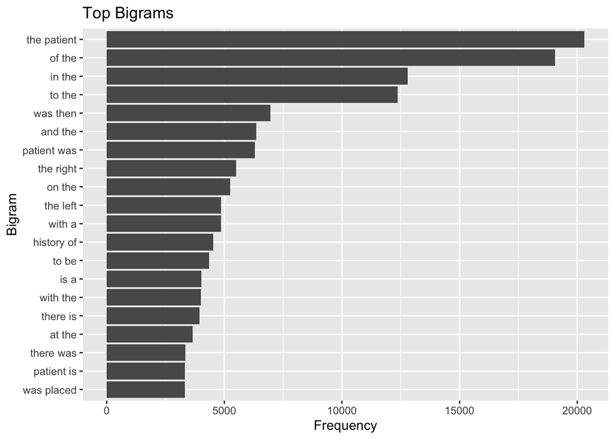

```r
#Bigrams
bigrams <- mtsamples %>%
  unnest_tokens(bigram, transcription, token = "ngrams", n = 2)

bigram_counts <- bigrams %>%
  count(bigram, sort = TRUE)


bigram_counts %>%
  slice_max(n, n = 20) %>%
  ggplot(aes(x = reorder(bigram, n), y = n)) +
  geom_col() +
  coord_flip() +
  labs(title = "Top Bigrams",
       x = "Bigram",
       y = "Frequency")
```

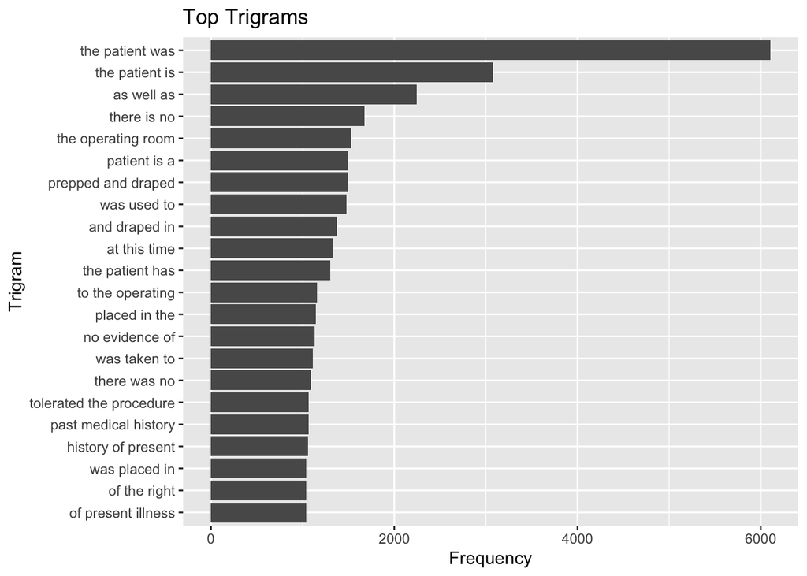

```r
#Trigrams
trigrams <- mtsamples %>%
  unnest_tokens(trigram, transcription, token = "ngrams", n = 3)

trigram_counts <- trigrams %>%
  count(trigram, sort = TRUE)

trigram_counts %>%
  slice_max(n, n = 20) %>%
  ggplot(aes(x = reorder(trigram, n), y = n)) +
  geom_col() +
  coord_flip() +
  labs(title = "Top Trigrams",
       x = "Trigram",
       y = "Frequency")
```

## Question 5

I chose blood because it is hardly used with “the” and it can be a compound words both at the front and back. The word before “blood” with the highest frequency is “estimated” (n=754), and the most frequent word after “blood” is “pressure” (n= 1265).

```r
bigram_separated <- bigrams %>%
  separate(bigram, into = c("word1", "word2"), sep = " ")

# Words before
bigram_separated %>%
  filter(word2 == "blood") %>%
  count(word1, sort = TRUE)
```

```
              word1   n
1         estimated 754
2             white 180
3             signs 170
4               and 154
5                of 149
6               red 123
7               her 116
8               his  99
9               the  96
10               no  72
11                a  68
12             high  55
13           pounds  48
14              for  45
```

[output cut: 425 more lines]

```r
# Words after
bigram_separated %>%
  filter(word1 == "blood") %>%
  count(word2, sort = TRUE)
```

```
               word2    n
1           pressure 1265
2               loss  965
3               cell  130
4                 in  114
5              cells  112
6              sugar   91
7                and   84
8             sugars   79
9                was   65
10          cultures   53
11              flow   45
12       transfusion   42
13              work   39
14           glucose   37
```

[output cut: 147 more lines]

## Question 6

The 5 most used words for each specialty were listed in a tibble. Some interesting pairs were showed up including Endocrinology-thyroid (n=129), Dentistry-tooth (n=108), and Obstetrics / Gynecology-uterus (n=317)

```r
# Remove stop words
top_words_specialty <- mtsamples %>%
  unnest_tokens(word, transcription) %>%
  anti_join(stop_words, by = "word") %>%
  filter(!str_detect(word, "^[0-9]+$")) %>%
  count(medical_specialty, word, sort = TRUE)

# specialty-specific words
top_words_specialty %>%
  group_by(medical_specialty) %>%
  top_n(5, n) %>%
  arrange(medical_specialty, desc(n))
```

```
# A tibble: 210 × 3
# Groups:   medical_specialty [40]
   medical_specialty       word          n
   <chr>                   <chr>     <int>
 1 " Allergy / Immunology" history      38
 2 " Allergy / Immunology" noted        23
 3 " Allergy / Immunology" patient      22
 4 " Allergy / Immunology" allergies    21
 5 " Allergy / Immunology" nasal        13
 6 " Allergy / Immunology" past         13
 7 " Autopsy"              left         83
 8 " Autopsy"              inch         59
 9 " Autopsy"              neck         55
10 " Autopsy"              anterior     47
# ℹ 200 more rows
```

## Question 7 - extra

I looked for specialty specific words by using TF-IDF (Term Frequency-Inverse Document Frequency) with bind_tf_idf() and listed up the top 3 high TF-IDF words in each specialty. One interesting finding is Cosmetic / Plastic Surgery has breast, midface, and nipple indicating they are dealing more breast or face than other specialty. Neurology has cn (Cranial Nerves), fhx(Family History), and shx (Social History). One possible interpretation is that the field uses more abbrebiation than other field.

```r
## TF-IDF words in specialty
tfidf_words <- mtsamples |>
  filter(!is.na(transcription)) |>
  unnest_tokens(word, transcription) |>
  anti_join(stop_words, by = "word") |>
  filter(!grepl("^[0-9]+$", word)) |>
  count(medical_specialty, word, sort = TRUE) |>
  bind_tf_idf(word, medical_specialty, n) |>
  arrange(medical_specialty, desc(tf_idf))
#tfidf_words


## The most characteristical word (Highest TF-IDF) in one specialty
unique_words_by_specialty <- tfidf_words |>
  group_by(medical_specialty) |>
  slice_max(tf_idf, n = 3, with_ties = FALSE) |>
  ungroup() |>
  select(medical_specialty, word, tf_idf)
unique_words_by_specialty
```

```
# A tibble: 120 × 3
   medical_specialty             word       tf_idf
   <chr>                         <chr>       <dbl>
 1 " Allergy / Immunology"       ivig      0.00652
 2 " Allergy / Immunology"       allegra   0.00648
 3 " Allergy / Immunology"       inhalant  0.00578
 4 " Autopsy"                    petechial 0.00983
 5 " Autopsy"                    ligature  0.00817
 6 " Autopsy"                    furrow    0.00750
 7 " Bariatrics"                 gastric   0.00667
 8 " Bariatrics"                 roux      0.00521
 9 " Bariatrics"                 bypass    0.00518
10 " Cardiovascular / Pulmonary" artery    0.00360
# ℹ 110 more rows
```